# Assignment 11

```python
import pandas as pd
import seaborn as sns
```

```python
penguins = sns.load_dataset("penguins")
penguins.head()
```

|  | species | island | bill_length_mm | bill_depth_mm | flipper_length_mm | body_mass_g | sex |
| --- | --- | --- | --- | --- | --- | --- | --- |
| 0 | Adelie | Torgersen | 39.1 | 18.7 | 181.0 | 3750.0 | Male |
| 1 | Adelie | Torgersen | 39.5 | 17.4 | 186.0 | 3800.0 | Female |
| 2 | Adelie | Torgersen | 40.3 | 18.0 | 195.0 | 3250.0 | Female |
| 3 | Adelie | Torgersen | NaN | NaN | NaN | NaN | NaN |
| 4 | Adelie | Torgersen | 36.7 | 19.3 | 193.0 | 3450.0 | Female |

```python
penguins.groupby("species").mean()
```

| species | bill_length_mm | bill_depth_mm | flipper_length_mm | body_mass_g |
| --- | --- | --- | --- | --- |
| Adelie | 38.791391 | 18.346358 | 189.953642 | 3700.662252 |
| Chinstrap | 48.833824 | 18.420588 | 195.823529 | 3733.088235 |
| Gentoo | 47.504878 | 14.982114 | 217.186992 | 5076.016260 |

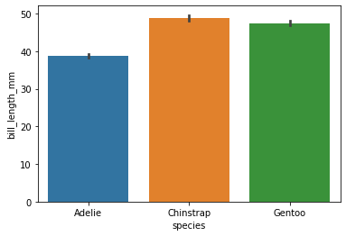

```python
sns.barplot(y="bill_length_mm", x="species", data=penguins)
```

Adelie has the smallest bill_length. Gentoo and Chinstrap are around the same length but in average the measured chinstraps have a larger bill.

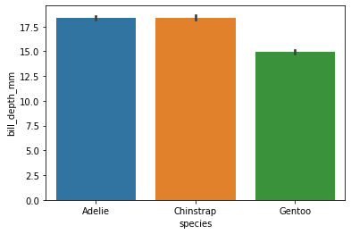

```python
sns.barplot(y="bill_depth_mm", x="species", data=penguins)
```

Gentoo has the smallest bill_depth while the others together have the largest.

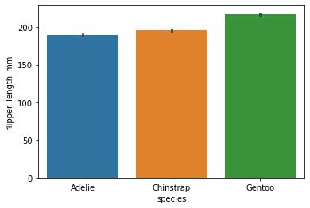

```python
sns.barplot(y="flipper_length_mm", x="species", data=penguins)
```

Gentoo has the largest flipper, after that the chinstrap and after that the Adelie.

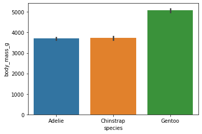

```python
sns.barplot(y="body_mass_g", x="species", data=penguins)
```

The Gentoo species seems to be way heavier than the other species who average out to the same mass. This gives me the image combined with the flipper length that the gentoo species is a taller penguin than the other species. Without having seen an image.

# Assignment 12

```python
vgSales = pd.read_csv("../Assignment 4/vgsales.csv")
vgSales.head()
```

|  | Rank | Name | basename | Genre | ESRB_Rating | Platform | Publisher | Developer | VGChartz_Score | Critic_Score | ... | NA_Sales | PAL_Sales | JP_Sales | Other_Sales | Year | Last_Update | url | status | Vgchartzscore | img_url |
| --- | --- | --- | --- | --- | --- | --- | --- | --- | --- | --- | --- | --- | --- | --- | --- | --- | --- | --- | --- | --- | --- |
| 0 | 1 | Wii Sports | wii-sports | Sports | E | Wii | Nintendo | Nintendo EAD | NaN | 7.7 | ... | NaN | NaN | NaN | NaN | 2006.0 | NaN | http://www.vgchartz.com/game/2667/wii-sports/?... | 1 | NaN | /games/boxart/full_2258645AmericaFrontccc.jpg |
| 1 | 2 | Super Mario Bros. | super-mario-bros | Platform | NaN | NES | Nintendo | Nintendo EAD | NaN | 10.0 | ... | NaN | NaN | NaN | NaN | 1985.0 | NaN | http://www.vgchartz.com/game/6455/super-mario-... | 1 | NaN | /games/boxart/8972270ccc.jpg |
| 2 | 3 | Mario Kart Wii | mario-kart-wii | Racing | E | Wii | Nintendo | Nintendo EAD | NaN | 8.2 | ... | NaN | NaN | NaN | NaN | 2008.0 | 11th Apr 18 | http://www.vgchartz.com/game/6968/mario-kart-w... | 1 | 8.7 | /games/boxart/full_8932480AmericaFrontccc.jpg |
| 3 | 4 | PlayerUnknown's Battlegrounds | playerunknowns-battlegrounds | Shooter | NaN | PC | PUBG Corporation | PUBG Corporation | NaN | NaN | ... | NaN | NaN | NaN | NaN | 2017.0 | 13th Nov 18 | http://www.vgchartz.com/game/215988/playerunkn... | 1 | NaN | /games/boxart/full_8052843AmericaFrontccc.jpg |
| 4 | 5 | Wii Sports Resort | wii-sports-resort | Sports | E | Wii | Nintendo | Nintendo EAD | NaN | 8.0 | ... | NaN | NaN | NaN | NaN | 2009.0 | NaN | http://www.vgchartz.com/game/24656/wii-sports-... | 1 | 8.8 | /games/boxart/full_7295041AmericaFrontccc.jpg |

5 rows × 23 columns

```python
vgSales.groupby("Genre").mean()
```

| Genre | Rank | VGChartz_Score | Critic_Score | User_Score | Total_Shipped | Global_Sales | NA_Sales | PAL_Sales | JP_Sales | Other_Sales | Year | status | Vgchartzscore |
| --- | --- | --- | --- | --- | --- | --- | --- | --- | --- | --- | --- | --- | --- |
| Action | 27082.658276 | NaN | 6.840234 | 8.076923 | 1.220675 | 0.414288 | 0.288757 | 0.167284 | 0.090731 | 0.051398 | 2005.668453 | 1.0 | 7.080000 |
| Action-Adventure | 26818.858785 | NaN | 7.693939 | 8.100000 | 0.992099 | 0.604864 | 0.314074 | 0.286743 | 0.062222 | 0.080041 | 2014.290844 | 1.0 | 6.616667 |
| Adventure | 29023.237483 | NaN | 7.329188 | 8.415625 | 1.101034 | 0.181431 | 0.198256 | 0.106371 | 0.049815 | 0.029120 | 2006.243217 | 1.0 | 7.432258 |
| Board Game | 49039.062500 | NaN | 5.300000 | NaN | NaN | 0.155000 | 0.060000 | 0.220000 | 0.010000 | 0.020000 | 2018.000000 | 1.0 | NaN |
| Education | 33624.416667 | NaN | 7.500000 | NaN | 0.165000 | 0.090000 | 0.080000 | NaN | NaN | 0.010000 | 2003.666667 | 1.0 | NaN |
| Fighting | 26102.436930 | NaN | 7.388415 | 8.654545 | 2.436885 | 0.404422 | 0.302923 | 0.143328 | 0.128943 | 0.043983 | 2004.401851 | 1.0 | 7.655556 |
| MMO | 23136.878378 | NaN | 7.810000 | 8.633333 | 2.308333 | 0.370625 | 0.244000 | 0.171000 | 0.147500 | 0.051739 | 2014.388889 | 1.0 | NaN |
| Misc | 30664.280604 | NaN | 6.885799 | 7.414286 | 2.064765 | 0.263185 | 0.248691 | 0.123384 | 0.081346 | 0.038713 | 2007.939849 | 1.0 | 7.290000 |
| Music | 18322.897436 | NaN | 7.912000 | 9.300000 | 1.170000 | 0.369301 | 0.276383 | 0.170337 | 0.134800 | 0.044107 | 2014.746114 | 1.0 | 7.950000 |
| Party | 30280.680000 | NaN | 6.053333 | NaN | 3.913333 | 0.207308 | 0.106818 | 0.107333 | 0.190000 | 0.019583 | 2013.594203 | 1.0 | 5.733333 |
| Platform | 28821.389550 | NaN | 7.308333 | 8.435897 | 2.891608 | 0.437188 | 0.275030 | 0.147119 | 0.161485 | 0.039880 | 2002.648329 | 1.0 | 7.607463 |
| Puzzle | 31775.619545 | NaN | 7.200000 | 8.037500 | 1.186344 | 0.184854 | 0.142063 | 0.053832 | 0.175621 | 0.012433 | 2005.651783 | 1.0 | 7.450000 |
| Racing | 24485.932673 | NaN | 7.091145 | 8.500000 | 4.176290 | 0.380090 | 0.226499 | 0.153747 | 0.083865 | 0.041956 | 2004.497999 | 1.0 | 7.882222 |
| Role-Playing | 26781.715667 | NaN | 7.461610 | 8.532203 | 2.202027 | 0.314218 | 0.225489 | 0.125887 | 0.151142 | 0.036238 | 2005.912634 | 1.0 | 7.657377 |
| Sandbox | 22364.000000 | NaN | 9.200000 | NaN | 0.284000 | 1.890000 | 0.690000 | 0.560000 | 0.520000 | 0.120000 | 2014.222222 | 1.0 | NaN |
| Shooter | 27784.223724 | NaN | 7.286833 | 8.143636 | 2.007708 | 0.693760 | 0.454234 | 0.257192 | 0.082661 | 0.079979 | 2004.399644 | 1.0 | 7.614433 |
| Simulation | 25717.486664 | NaN | 6.926201 | 8.050000 | 1.262941 | 0.283469 | 0.226586 | 0.127932 | 0.127455 | 0.027695 | 2005.957297 | 1.0 | 6.860000 |
| Sports | 23421.281846 | NaN | 7.291424 | 7.887500 | 4.368519 | 0.469137 | 0.316358 | 0.186379 | 0.169925 | 0.057109 | 2003.431203 | 1.0 | 7.242500 |
| Strategy | 30438.502756 | NaN | 7.429268 | 7.846154 | 0.807986 | 0.167698 | 0.147500 | 0.061182 | 0.149967 | 0.013030 | 2004.599813 | 1.0 | 7.650000 |
| Visual Novel | 34544.384615 | NaN | 8.500000 | NaN | 0.253571 | 0.030439 | 0.036154 | 0.010000 | 0.025505 | 0.008000 | 2015.914634 | 1.0 | 7.000000 |

Critic_Score has a decent amount of variation when it comes to sorting on genre. I also find it interesting that party and racing games have alot of shipped games average yet Action and Adventure are really low. This is probably because the amount of action games is way higher compared to racing and party games. Thus the average will be way lower.

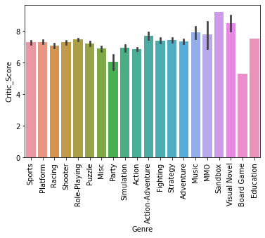

```python
graph = sns.barplot(y="Critic_Score", x="Genre", data=vgSales)
graph.set_xticklabels(graph.get_xticklabels(), rotation=90)
graph
```

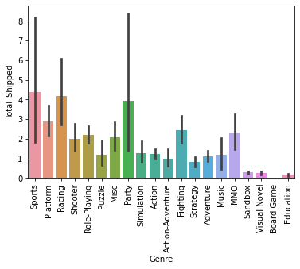

```python
graph = sns.barplot(y="Total_Shipped", x="Genre", data=vgSales)
graph.set_xticklabels(graph.get_xticklabels(), rotation=90)
graph
```

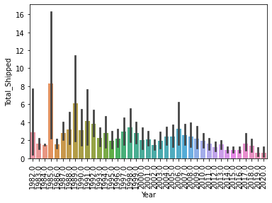

```python
graph = sns.barplot(y="Total_Shipped", x="Year", data=vgSales[(vgSales.Year > 1981)])
graph.set_xticklabels(graph.get_xticklabels(), rotation=90)
graph
```